# **Final Project - Unit 2: Data Understanding**

**10) First, create a Heatmap of Missing Values within the Dataset:**

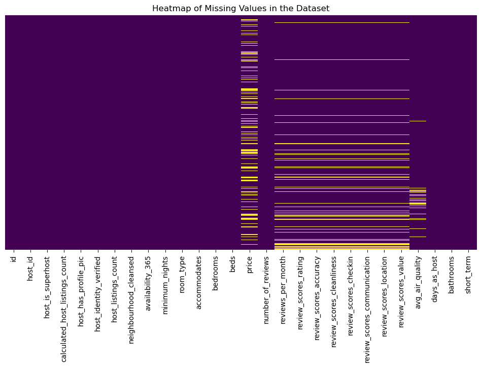

```python
# replace with code to produce heatmap of missing (and non missing) data
plt.figure(figsize=(12,6))
sns.heatmap(df2.isnull(), cmap='viridis', cbar=False, yticklabels=False)
plt.title("Heatmap of Missing Values in the Dataset")
plt.show()
```

**11) List which variables within the dataset contain missing values, as well as the percentage of data that is missing for that variable. *Hint: If there are any groupings of similar missing variables that share the same proportion of misisng data, you can list them as one group, instead of all individually*.**

```python
# fill in the variable(s) you want to examine the missing values of
missing_data = df2.isnull().sum() * 100 / len(df2)
missing_data = missing_data[missing_data > 0].sort_values(ascending=False)
for var, percent in missing_data.items():
    print(f"{var}: {percent:.2f}% missing")
```

```
price: 25.19% missing
reviews_per_month: 10.43% missing
review_scores_rating: 10.43% missing
review_scores_accuracy: 10.43% missing
review_scores_cleanliness: 10.43% missing
review_scores_checkin: 10.43% missing
review_scores_communication: 10.43% missing
review_scores_location: 10.43% missing
review_scores_value: 10.43% missing
avg_air_quality: 4.83% missing
```

- price: 25.19% missing
- reviews_per_month: 10.43% missing
- review_scores_rating: 10.43% missing
- review_scores_accuracy: 10.43% missing
- review_scores_cleanliness: 10.43% missing
- review_scores_checkin: 10.43% missing
- review_scores_communication: 10.43% missing
- review_scores_location: 10.43% missing
- review_scores_value: 10.43% missing
- avg_air_quality: 4.83% missing

**12) Are there any variables with complete data (no missing values) that could be related to the missingness seen in the multitude of *review* variables with missing data? If so, what does this indicate about the type of missing data these variables have?**

```python
df2.info()
```

```
<class 'pandas.core.frame.DataFrame'>
RangeIndex: 8808 entries, 0 to 8807
Data columns (total 28 columns):
 #   Column                          Non-Null Count  Dtype
---  ------                          --------------  -----
 0   id                              8808 non-null   float64
 1   host_id                         8808 non-null   int64
 2   host_is_superhost               8808 non-null   int64
 3   calculated_host_listings_count  8808 non-null   int64
 4   host_has_profile_pic            8808 non-null   int64
 5   host_identity_verified          8808 non-null   int64
 6   host_listings_count             8808 non-null   int64
 7   neighbourhood_cleansed          8808 non-null   object
 8   availability_365                8808 non-null   int64
 9   minimum_nights                  8808 non-null   int64
```

[output cut: 20 more lines]

Yes there is, number_of_reviews is actually one

```python
# replace with code to compare the complete variable against one or more missing variables to confirm your above statement
review_cols = [col for col in df2.columns if "review" in col]

for col in review_cols:
    missing_vs_reviews = df2.groupby(df2[col].isnull())['number_of_reviews'].describe()
    print(f"Comparison of {col} missing values vs. number_of_reviews:\n{missing_vs_reviews}\n")
```

```
Comparison of number_of_reviews missing values vs. number_of_reviews:
                    count       mean         std  min  25%   50%   75%     max
number_of_reviews
False              8808.0  77.323569  125.542844  0.0  5.0  31.0  98.0  2603.0

Comparison of reviews_per_month missing values vs. number_of_reviews:
                    count       mean         std  min   25%   50%    75%  \
reviews_per_month
False              7889.0  86.331094  129.690134  1.0  10.0  40.0  109.0
True                919.0   0.000000    0.000000  0.0   0.0   0.0    0.0

                      max
reviews_per_month
False              2603.0
True                  0.0

Comparison of review_scores_rating missing values vs. number_of_reviews:
                       count       mean         std  min   25%   50%    75%  \
review_scores_rating
False                 7889.0  86.331094  129.690134  1.0  10.0  40.0  109.0
True                   919.0   0.000000    0.000000  0.0   0.0   0.0    0.0

                         max
review_scores_rating
False                 2603.0
True                     0.0

Comparison of review_scores_accuracy missing values vs. number_of_reviews:
                         count       mean         std  min   25%   50%    75%  \
review_scores_accuracy
False                   7889.0  86.331094  129.690134  1.0  10.0  40.0  109.0
True                     919.0   0.000000    0.000000  0.0   0.0   0.0    0.0

                           max
review_scores_accuracy
False                   2603.0
True                       0.0

Comparison of review_scores_cleanliness missing values vs. number_of_reviews:
                            count       mean         std  min   25%   50%  \
```

[output cut: 37 more lines]

```
                           max
review_scores_location
False                   2603.0
True                       0.0

Comparison of review_scores_value missing values vs. number_of_reviews:
                      count       mean         std  min   25%   50%    75%  \
review_scores_value
False                7889.0  86.331094  129.690134  1.0  10.0  40.0  109.0
True                  919.0   0.000000    0.000000  0.0   0.0   0.0    0.0

                        max
review_scores_value
False                2603.0
True                    0.0
```

```python
df2.info()
```

```
<class 'pandas.core.frame.DataFrame'>
RangeIndex: 8808 entries, 0 to 8807
Data columns (total 28 columns):
 #   Column                          Non-Null Count  Dtype
---  ------                          --------------  -----
 0   id                              8808 non-null   float64
 1   host_id                         8808 non-null   int64
 2   host_is_superhost               8808 non-null   int64
 3   calculated_host_listings_count  8808 non-null   int64
 4   host_has_profile_pic            8808 non-null   int64
 5   host_identity_verified          8808 non-null   int64
 6   host_listings_count             8808 non-null   int64
 7   neighbourhood_cleansed          8808 non-null   object
 8   availability_365                8808 non-null   int64
 9   minimum_nights                  8808 non-null   int64
```

[output cut: 20 more lines]

**13) Proposed Type of Missing Data:**

**Fill in the variables you believe fall under each type of missing data (it's fine if some missing data categories have no variables listed), and then briefly explain below why you think those variables are structurally missing, MCAR, MAR, or MNAR.**